# Homework 09

The kernel-tuning question moved here from Homework 08. A solution for Question 1 will be available after Monday, October 26, 2026. No solution can be provided for Question 2.

## Question 1: Choosing an SVM kernel

Use `saheart.csv` from the combined ZIP. As in Homework 7, predict `chd` using the same nine predictors, coding `famhist` as 1 for `Absent` and 2 for `Present`.

**Show the workflow**

```r
# Reuse code from homework-07
heart <- read.csv("data/saheart.csv")
heart$famhist <- factor(heart$famhist, levels = c("Absent", "Present"))
X <- data.matrix(heart[, names(heart) != "chd"])
y <- heart$chd
```

Compare SVMs with a linear kernel, polynomial kernels of degrees 2 (quadratic), 3, and 4, and a radial basis kernel. Choose **no more than 20 candidate settings in total** across these kernels. Vary the cost $C$ for each kernel and the radial scale $\gamma$ for the radial kernel. State any other kernel settings you hold fixed.

Divide the observations into five folds yourself and use the same folds for all candidates. Standardize predictors using only the fitting observations in each fold. Report the candidate settings and their mean cross-validation misclassification rates. Which kernel and settings do you prefer? Give a brief justification.

**Show the workflow**

```r
set.seed(43201)

# Reuse code from homework-07
heart <- read.csv("data/saheart.csv")
heart$famhist <- factor(heart$famhist, levels = c("Absent", "Present"))
X <- data.matrix(heart[, names(heart) != "chd"])
y <- heart$chd

# Divide the observations into five folds
library(caret)
folds <- createFolds(y = y, k = 5, list = TRUE, returnTrain = FALSE)

# Create training and testing data for each fold
# lapply(x, function()): run the function() once for each element of x
# lapply() returns a list of the same length as x
fold_data <- lapply(folds, function(test_index){

  # setdiff() removes the testing indices from X, which leaves the training indices
  train_index <- setdiff(seq_len(nrow(X)), test_index)

  # Assign training and testing data
  X_train <- X[train_index, , drop = FALSE]
  X_test <- X[test_index, , drop = FALSE]
  y_train <- y[train_index]
  y_test <- y[test_index]

  # Standardize predictors using only the training data in each fold
  # apply(X, MARGIN = 2, FUN) means the function will be applied over the columns
  train_center <- colMeans(X_train)
  train_sd <- apply(X_train, 2, sd)

  # scale() standardizes data by calculating Z-scores
  X_train_standard <- scale(X_train, center = train_center, scale = train_sd)
  X_test_standard <- scale(X_test, center = train_center, scale = train_sd)

  # Put the training and testing data into a list
  list(
    X_train = X_train_standard,
    y_train = y_train,
    X_test = X_test_standard,
    y_test = y_test
  )

})

# Fit a SVM with a linear kernel for 4 different costs
library(e1071)
cost <- c(0.1, 1, 10, 100)

# Calculate mean CV misclassification rate for each cost parameter
linear_mean_cv_errors <- vapply(cost, function(C){
  fold_errors <- vapply(fold_data, function(d){

    # Fit a linear SVM for each fold
    fit <- svm(x = d$X_train, y = factor(d$y_train), type = "C-classification",
               kernel = "linear", cost = C, scale = FALSE)

    predictions <- predict(fit, newdata = d$X_test)
    mean(predictions != factor(d$y_test))
  }, numeric(1))

  mean(fold_errors)
}, numeric(1))

# Fit a sVM with a polynomial kernel of degree 2 for 4 different costs
polynomial2_mean_cv_errors <- vapply(cost, function(C){
  fold_errors <- vapply(fold_data, function(d){

    # Fit a polynomial SVM of degrees 1 (quadratic) for each fold
    # gamma = 1 / (data dimension) = 1 / p where p = # of predictiors
    # coef0 is set to 0 so that the polynomial SVM only varies by degree and cost
    fit <- svm(x = d$X_train, y = factor(d$y_train), type = "C-classification",
               kernel = "polynomial", degree = 2, cost = C,
               gamma = 1 / ncol(d$X_train), coef0 = 0, scale = FALSE)

    predictions <- predict(fit, newdata = d$X_test)
    mean(predictions != factor(d$y_test))
  }, numeric(1))

  mean(fold_errors)
}, numeric(1))

# Fit a sVM with a polynomial kernel of degree 3 for 4 different costs
polynomial3_mean_cv_errors <- vapply(cost, function(C){
  fold_errors <- vapply(fold_data, function(d){

    # Fit a polynomial SVM of degrees 3 for each fold
    # Set degree = 3
    fit <- svm(x = d$X_train, y = factor(d$y_train), type = "C-classification",
               kernel = "polynomial", degree = 3, cost = C,
               gamma = 1 / ncol(d$X_train), coef0 = 0, scale = FALSE)

    predictions <- predict(fit, newdata = d$X_test)
    mean(predictions != factor(d$y_test))
  }, numeric(1))

  mean(fold_errors)
}, numeric(1))

# Fit a sVM with a polynomial kernel of degree 4 for 4 different costs
polynomial4_mean_cv_errors <- vapply(cost, function(C){
  fold_errors <- vapply(fold_data, function(d){

    # Fit a polynomial SVM of degrees 4 for each fold
    # Set degree = 4
    fit <- svm(x = d$X_train, y = factor(d$y_train), type = "C-classification",
               kernel = "polynomial", degree = 4, cost = C,
               gamma = 1 / ncol(d$X_train), coef0 = 0, scale = FALSE)

    predictions <- predict(fit, newdata = d$X_test)
    mean(predictions != factor(d$y_test))
  }, numeric(1))

  mean(fold_errors)
}, numeric(1))

# Fit a sVM with a radial kernel for 2 different costs
radial_cost <- c(1, 100)

radial1_mean_cv_errors <- vapply(radial_cost, function(C){
  fold_errors <- vapply(fold_data, function(d){

    # Fit a radial SVM with gamma = 1 / 9 for each fold
    fit <- svm(x = d$X_train, y = factor(d$y_train), type = "C-classification",
               kernel = "radial", cost = C,
               gamma = 1 / ncol(d$X_train), coef0 = 0, scale = FALSE)

    predictions <- predict(fit, newdata = d$X_test)
    mean(predictions != factor(d$y_test))
  }, numeric(1))

  mean(fold_errors)
}, numeric(1))

# Fit a sVM with a different radial kernel for 2 different costs
radial2_mean_cv_errors <- vapply(radial_cost, function(C){
  fold_errors <- vapply(fold_data, function(d){

    # Fit a radial SVM with gamma = 1 / 18 for each fold
    fit <- svm(x = d$X_train, y = factor(d$y_train), type = "C-classification",
               kernel = "radial", cost = C,
               gamma = 1 / 18, coef0 = 0, scale = FALSE)

    predictions <- predict(fit, newdata = d$X_test)
    mean(predictions != factor(d$y_test))
  }, numeric(1))

  mean(fold_errors)
}, numeric(1))

# Report the candidate settings and their mean CV misclassification rates
results <- rbind(
  # Linear SVM
  data.frame(
    kernel = "linear",
    degree = NA_integer_,
    cost = cost,
    gamma = NA_real_,
    mean_cv_error = linear_mean_cv_errors
  ),

  # Polynomial SVM of degrees 2
  data.frame(
    kernel = "polynomial",
    degree = 2,
    cost = cost,
    gamma = 1 / 9,
    mean_cv_error = polynomial2_mean_cv_errors
  ),

  # Polynomial SVM of degrees 3
  data.frame(
    kernel = "polynomial",
    degree = 3,
    cost = cost,
    gamma = 1 / 9,
    mean_cv_error = polynomial3_mean_cv_errors
  ),

  # Polynomial SVM of degrees 4
  data.frame(
    kernel = "polynomial",
    degree = 4,
    cost = cost,
    gamma = 1 / 9,
    mean_cv_error = polynomial4_mean_cv_errors
  ),

  # Radial SVM with gamma = 1 / 9
  data.frame(
    kernel = "radial",
    degree = NA_integer_,
    cost = radial_cost,
    gamma = 1 / 9,
    mean_cv_error = radial1_mean_cv_errors
  ),

  # Radial SVM with gamma = 1 / 18
  data.frame(
    kernel = "radial",
    degree = NA_integer_,
    cost = radial_cost,
    gamma = 1 / 18,
    mean_cv_error = radial2_mean_cv_errors
  )
)

results
```

```
       kernel degree  cost      gamma mean_cv_error
1      linear     NA   0.1         NA     0.2878448
2      linear     NA   1.0         NA     0.2813230
3      linear     NA  10.0         NA     0.2834970
4      linear     NA 100.0         NA     0.2834970
5  polynomial      2   0.1 0.11111111     0.3419822
6  polynomial      2   1.0 0.11111111     0.3181861
7  polynomial      2  10.0 0.11111111     0.3116877
8  polynomial      2 100.0 0.11111111     0.3009116
9  polynomial      3   0.1 0.11111111     0.3267648
10 polynomial      3   1.0 0.11111111     0.2878448
11 polynomial      3  10.0 0.11111111     0.3072464
12 polynomial      3 100.0 0.11111111     0.3397849
13 polynomial      4   0.1 0.11111111     0.3311360
14 polynomial      4   1.0 0.11111111     0.3225105
15 polynomial      4  10.0 0.11111111     0.3289621
16 polynomial      4 100.0 0.11111111     0.3896447
17     radial     NA   1.0 0.11111111     0.2878448
18     radial     NA 100.0 0.11111111     0.3679991
19     radial     NA   1.0 0.05555556     0.2856709
20     radial     NA 100.0 0.05555556     0.3289855
```

For the polynomial kernels, $\gamma = 1 / 9$ and $coef0 = 0$ for degrees 2, 3, and 4. According to the results above, I would prefer a linear kernel with $C = 1$ because it has the lowest mean cross-validation misclassification rate. The polynomial kernels for degrees 2, 3, and 4 generally did worse than the linear and radial kernels because their mean CV error was higher than the other kernels.

## Question 2: Write and use a short SVM analysis skill

In Homework 8, you reviewed another student’s skill. Review the comments and suggestions you received on your own Homework 7 skill. Use what you learned from both sides of the peer review to write a new, shorter skill for SVM model fitting.

**Write the skill by hand.** Create a `SKILL.md` with a short name and description in YAML frontmatter. Write the entire file yourself, without asking AI to draft or edit it. The instruction body after the closing `---` of the frontmatter must be **no more than 50 lines**, including blank lines. Keep the skill independent of any particular dataset, variable names, or observed results, and load it only when you explicitly invoke it.

Your skill should direct the agent to:

1. judge whether the data are suitable for an SVM analysis;
2. choose which kernels to consider and explain why;
3. identify tuning parameters and a method for tuning them;
4. choose an evaluation method that supports selecting a final model;
5. require a compact figure and table that justify the choices;
6. interpret the fit and report the key numerical results; and
7. prioritize the evidence needed to justify the final model in **no more than one printed page at 11-point font**.

**Apply the skill.** Explicitly invoke your skill to analyze `saheart.csv`, using the same response, nine predictors, and `famhist` coding as in Question 1. Provide these data details when invoking the skill, not in the skill itself. Let the skill guide the analysis, then check the resulting report and calculations.

**Submit the results.** Include the one-page, 11-point analysis report in your Homework 09 submission and append the complete contents of your `SKILL.md` afterward. The appended skill is outside the one-page limit.

### Final one-page, 11-point analysis report

**Show the workflow**

```r
library(caret)
library(e1071)
library(ggplot2)
library(knitr)

set.seed(43201)
heart <- read.csv("data/saheart.csv")
heart$famhist <- factor(heart$famhist, levels = c("Absent", "Present"))
y <- factor(heart$chd, levels = c(0, 1))
X <- data.matrix(heart[, names(heart) != "chd"])

stopifnot(!anyNA(X), !anyNA(y), all(is.finite(X)))
```

We predict binary coronary heart disease (`chd`, 0/1; 462 observations) from nine numeric predictors in `saheart.csv`; `famhist` is coded Absent = 1 and Present = 2. Linear and nonlinear SVMs compare whether a flexible boundary improves prediction.

With seed 43201, a stratified 80/20 split reserved a test set. Stratified five-fold CV on training data selected among 20 candidates; the untouched test set estimates generalization after tuning. Scaling was learned within each fold. Candidates: linear (`C = 0.1, 1, 10, 100`); polynomial degrees 2–4 at those costs (`gamma = 1/9`, `coef0 = 0`); radial (`C = 1, 100`; `gamma = 1/9, 1/18`). Fits used `scale = FALSE`.

**Show the workflow**

```r
training_index <- createDataPartition(y, p = 0.8, list = FALSE)
X_training <- X[training_index, , drop = FALSE]
y_training <- y[training_index]
X_test <- X[-training_index, , drop = FALSE]
y_test <- y[-training_index]
folds <- createFolds(y_training, k = 5, list = TRUE, returnTrain = FALSE)

costs <- c(0.1, 1, 10, 100)
candidate_grid <- rbind(
  data.frame(kernel = "linear", degree = NA_integer_, cost = costs,
             gamma = NA_real_, coef0 = NA_real_),
  do.call(rbind, lapply(2:4, function(d) {
    data.frame(kernel = "polynomial", degree = d, cost = costs,
               gamma = 1 / ncol(X), coef0 = 0)
  })),
  expand.grid(kernel = "radial", degree = NA_integer_, cost = c(1, 100),
              gamma = c(1 / 9, 1 / 18), coef0 = NA_real_)
)

fit_candidate <- function(x, response, candidate) {
  args <- list(
    x = x, y = response, type = "C-classification",
    kernel = candidate$kernel, cost = candidate$cost, scale = FALSE
  )
  if (candidate$kernel == "polynomial") {
    args$degree <- candidate$degree
    args$gamma <- candidate$gamma
    args$coef0 <- candidate$coef0
  } else if (candidate$kernel == "radial") {
    args$gamma <- candidate$gamma
  }
  do.call(e1071::svm, args)
}

fold_error <- matrix(NA_real_, nrow(candidate_grid), length(folds))
for (i in seq_len(nrow(candidate_grid))) {
  candidate <- candidate_grid[i, ]
  for (j in seq_along(folds)) {
    validation_index <- folds[[j]]
    fitting_index <- setdiff(seq_len(nrow(X_training)), validation_index)
    x_fit <- X_training[fitting_index, , drop = FALSE]
    center <- colMeans(x_fit)
    spread <- apply(x_fit, 2, sd)
    x_fit <- scale(x_fit, center = center, scale = spread)
    x_validation <- scale(
      X_training[validation_index, , drop = FALSE],
      center = center, scale = spread
    )
    fit <- fit_candidate(x_fit, y_training[fitting_index], candidate)
    predicted <- predict(fit, newdata = x_validation)
    fold_error[i, j] <- mean(predicted != y_training[validation_index])
  }
}

candidate_grid$mean_cv_error <- rowMeans(fold_error)
candidate_grid$cv_sd <- apply(fold_error, 1, sd)
best_index <- which.min(candidate_grid$mean_cv_error)
selected <- candidate_grid[best_index, ]

center <- colMeans(X_training)
spread <- apply(X_training, 2, sd)
X_training_standard <- scale(X_training, center = center, scale = spread)
X_test_standard <- scale(X_test, center = center, scale = spread)
final_fit <- fit_candidate(X_training_standard, y_training, selected)
test_prediction <- predict(final_fit, newdata = X_test_standard)
test_error <- mean(test_prediction != y_test)
test_accuracy <- 1 - test_error
test_confusion <- table(Predicted = test_prediction, Observed = y_test)
true_negative <- unname(test_confusion["0", "0"])
false_positive <- unname(test_confusion["1", "0"])
false_negative <- unname(test_confusion["0", "1"])
true_positive <- unname(test_confusion["1", "1"])
test_sensitivity <- true_positive / (true_positive + false_negative)
test_specificity <- true_negative / (true_negative + false_positive)

candidate_label <- ifelse(
  candidate_grid$kernel == "linear",
  sprintf("Lin C=%g", candidate_grid$cost),
  ifelse(
    candidate_grid$kernel == "polynomial",
    sprintf("Poly%d C=%g", candidate_grid$degree, candidate_grid$cost),
    sprintf("RBF C=%g g=%.3g", candidate_grid$cost, candidate_grid$gamma)
  )
)
candidate_grid$candidate <- candidate_label
candidate_grid$selected <- seq_len(nrow(candidate_grid)) == best_index
selected_label <- paste0(
  selected$kernel,
  if (selected$kernel == "polynomial") paste0(" degree ", selected$degree) else "",
  " SVM"
)
selected_summary <- sprintf(
  "%s (C = %g%s) had mean CV error %.3f (fold SD %.3f). On the untouched %d-observation test set, accuracy was %.1f%% (error %.1f%%), sensitivity %.1f%%, and specificity %.1f%%.",
  selected_label,
  selected$cost,
  if (selected$kernel == "linear") "" else sprintf(", gamma = %.3g", selected$gamma),
  selected$mean_cv_error,
  selected$cv_sd,
  length(y_test),
  100 * test_accuracy,
  100 * test_error,
  100 * test_sensitivity,
  100 * test_specificity
)
class_balance_note <- sprintf(
  "The %.1f%% sensitivity versus %.1f%% specificity shows that low overall error did not translate to similarly strong detection of CHD-positive cases.",
  100 * test_sensitivity,
  100 * test_specificity
)
confusion_table <- data.frame(
  Predicted = c("0 (negative)", "1 (positive)"),
  `Observed 0` = c(
    sprintf("%d (TN)", true_negative),
    sprintf("%d (FP)", false_positive)
  ),
  `Observed 1` = c(
    sprintf("%d (FN)", false_negative),
    sprintf("%d (TP)", true_positive)
  ),
  check.names = FALSE
)

table_rows <- data.frame(
  Candidate_1 = candidate_grid$candidate[1:10],
  CV_error_1 = sprintf("%.3f", candidate_grid$mean_cv_error[1:10]),
  Candidate_2 = candidate_grid$candidate[11:20],
  CV_error_2 = sprintf("%.3f", candidate_grid$mean_cv_error[11:20])
)
selected_labels <- candidate_grid$candidate[candidate_grid$selected]
table_rows$Candidate_1[table_rows$Candidate_1 == selected_labels] <-
  paste0("* ", selected_labels)
table_rows$Candidate_2[table_rows$Candidate_2 == selected_labels] <-
  paste0("* ", selected_labels)
```

## Cross-validation results

**Show the workflow**

```r
knitr::kable(
  table_rows,
  format = "html",
  col.names = c("Candidate", "Mean CV error", "Candidate", "Mean CV error"),
  align = c("l", "c", "l", "c"),
  caption = "* marks the candidate selected by the lowest mean CV error."
)
```

* marks the candidate selected by the lowest mean CV error.

| Candidate | Mean CV error | Candidate | Mean CV error |
| --- | --- | --- | --- |
| Lin C=0.1 | 0.300 | Poly3 C=10 | 0.335 |
| Lin C=1 | 0.295 | Poly3 C=100 | 0.351 |
| Lin C=10 | 0.300 | Poly4 C=0.1 | 0.335 |
| Lin C=100 | 0.300 | Poly4 C=1 | 0.343 |
| Poly2 C=0.1 | 0.341 | Poly4 C=10 | 0.368 |
| Poly2 C=1 | 0.332 | Poly4 C=100 | 0.400 |
| Poly2 C=10 | 0.349 | * RBF C=1 g=0.111 | 0.286 |
| Poly2 C=100 | 0.335 | RBF C=100 g=0.111 | 0.384 |
| Poly3 C=0.1 | 0.324 | RBF C=1 g=0.0556 | 0.292 |
| Poly3 C=1 | 0.305 | RBF C=100 g=0.0556 | 0.332 |

**Show the workflow**

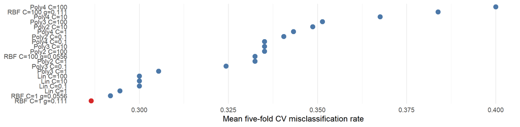

Mean five-fold CV error for each candidate; red marks the minimum and selected SVM.

```r
ggplot(candidate_grid, aes(
  x = reorder(candidate, mean_cv_error),
  y = mean_cv_error,
  color = selected
)) +
  geom_point(size = 2.3) +
  coord_flip() +
  scale_color_manual(values = c(`FALSE` = "#4C78A8", `TRUE` = "#D62728")) +
  labs(x = NULL, y = "Mean five-fold CV misclassification rate") +
  theme_minimal(base_size = 9) +
  theme(
    legend.position = "none",
    axis.text.y = element_text(size = 7.5),
    panel.grid.major.y = element_blank()
  )
```

**Selection and test result:** radial SVM (C = 1, gamma = 0.111) had mean CV error 0.286 (fold SD 0.011). On the untouched 92-observation test set, accuracy was 78.3% (error 21.7%), sensitivity 43.8%, and specificity 96.7%. The 43.8% sensitivity versus 96.7% specificity shows that low overall error did not translate to similarly strong detection of CHD-positive cases.

**Show the workflow**

```r
knitr::kable(
  confusion_table,
  format = "html",
  col.names = c("Predicted class", "Actual CHD = 0", "Actual CHD = 1"),
  align = c("l", "c", "c"),
  caption = "Held-out test-set confusion matrix; cells identify TN, FP, FN, and TP."
)
```

Held-out test-set confusion matrix; cells identify TN, FP, FN, and TP.

| Predicted class | Actual CHD = 0 | Actual CHD = 1 |
| --- | --- | --- |
| 0 (negative) | 58 (TN) | 18 (FN) |
| 1 (positive) | 2 (FP) | 14 (TP) |

The test estimate is based on one split and is therefore uncertain. This skill analysis uses CV only within the training partition before one test evaluation; the homework’s Question 1 separately asks for five-fold CV over the full dataset.

### Complete `SKILL.md`

```markdown
---
name: SVM-analysis
description: "Use only when explicitly invoked to compare SVM classifiers, select a model with cross-validation, evaluate it once on a reserved test set, and write a concise statistical report."
user-invocable: true
disable-model-invocation: true
---

## SVM Analysis

Use this workflow only when the user explicitly invokes this skill and supplies the dataset, response, and predictors. Do not assume variable names, class count, coding, or results. Ask for missing inputs before analysis. Use only SVM or combinations of their predicted class probabilities as classifiers.

## Analysis Procedure

1.  Identify the response, predictors, class labels, and any required coding. Check for missing/non-numeric predictors and class counts. Determine if the data are suitable for an SVM analysis.
2.  Set and report a random seed. Choose which kernels to consider and explain why.
3.  Identify tuning parameters and use cross-validation to tune them.
4.  Choose an evaluation method that supports selecting a final model and explain why.

## Report Requirements

Create the analysis report as a Quarto `.qmd` file, following the structure and conventions of the user's homework `.qmd` files. Configure it to render as `.html`, run the document, and verify that the rendered HTML is current and opens successfully.

Produce a clearly readable analysis report that fits on at most one printed page at 11-point font. Include:

- A brief background information about the data and why an SVM analysis is required;

- A compact table of candidate settings, their average CV misclassification rates, and the selected model;

- A figure that justifies choosing the final model and a caption that explains what the figure is and why the final model is selected;

- A compact table showing True Negative (TN), False Positive (FP), False Negative (FN), and True Positive (TP);

- A brief description of candidates and CV procedure, the selection, main findings, and limitations;

- Interpretation of the fit and key numerical results;

- Prioritize evidence needed to justify the final model.
```